# Fourth Week: Hypothesis Testing

TIMSS Analysis

Mina Moosavifar - 93106788

2018-03-09 00:16:06

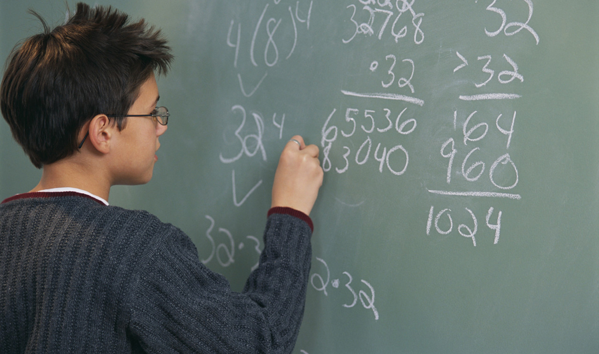

# تمرین سری چهارم: چقدر ریاضی بلدیم و چرا؟

لطفا مقاله زیر را مطالعه بفرمایید.

[چرایی رتبه ضعیف ایران در آزمون تیمز](https://goo.gl/gX8DZc)

> با استفاده از داده های ارزیابی تیمز ۲۰۱۵ ادعاهای زیر را مورد ارزیابی قراردهید. برای هر سوال علاوه بر استدلال آماری که در غالب آزمون فرض تعریف می شود از تصویرسازی مناسب باهر دو ابزار ggplot2 و highcharter استفاده نمایید. به دلخواه به هفت گزاره از موارد زیر پاسخ دهید.

لود داده ها و کتابخانه ها)

```r
library(readr)
library(dplyr)
library(ggplot2)
library(highcharter)
library(tidyr)

bcg = read_rds("tims/data/bcg.rds") # school background
bsg = read_rds("tims/data/bsg.rds") # student background
btg = read_rds("tims/data/btm.rds") # Teacher background
bsa = read_rds("tims/data/bsa.rds") # student result
bst = read_rds("tims/data/bst.rds") # student-teacher linkage
bsr = read_rds("tims/data/bsr.rds") # within-country
tims = read_rds("tims/timss_2015.rds")
```

۱. میران رضایت معلمان در پیشرفت تحصیلی دانش آموزان موثر است.

برای این سوال برای بدست آوردن رضایت معلمان از ستون BTDGTJS در داده ی btm استفاده می کنیم. هم چنین برای امتیاز دانش آموز میان ستون نمرات علوم و ریاضی میانگین میگیریم. در نهایت این دو داده را بر اساس کشور و شناسه ی معلم join می کنیم.

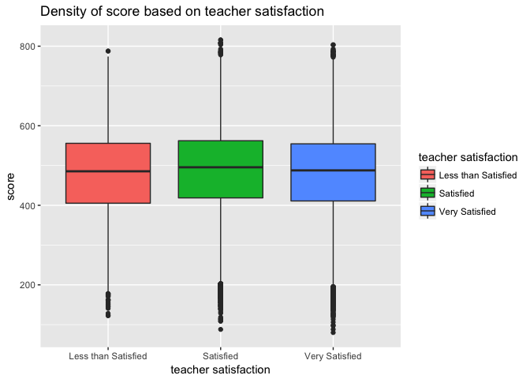

```r
tchr_std_perf <- bst %>% select(country= idcntry, teacher= idteach, student= idstud, contains("bsssci"), contains("bsmmat")) %>%
  mutate(score = rowMeans(.[, 4:13])) %>%
  select(country, teacher, student, score) %>%
  filter(!is.na(country) & !is.na(teacher) & !is.na(student) & !is.na(score))

tchr_sat <-  btg %>% select(country= idcntry, teacher= idteach, sat=btdgtjs) %>%
  filter(!is.na(country) & !is.na(teacher) & !is.na(sat))

tchr_sat_std_perf <- tchr_std_perf %>% inner_join(tchr_sat, by= c("country", "teacher")) %>%
  mutate(satisfaction = ifelse(sat == 1, "Very Satisfied",
                ifelse(sat == 2, "Satisfied",
                       ifelse(sat == 3, "Less than Satisfied", NA)))) %>%
  select(country, teacher, score, satisfaction)

tchr_sat_std_perf %>% ggplot(mapping = aes(satisfaction, score, fill = satisfaction)) +
  geom_boxplot(notch=FALSE) +
  ylab("score") +
  xlab("teacher satisfaction") +
  ggtitle("Density of score based on teacher satisfaction") +
  guides(fill=guide_legend(title="teacher satisfaction"))
```

```r
group1 <- tchr_sat_std_perf %>% filter(satisfaction == "Very Satisfied")
group2 <- tchr_sat_std_perf %>% filter(satisfaction == "Satisfied")
group3 <- tchr_sat_std_perf %>% filter(satisfaction == "Less than Satisfied")

hchart(density(group1$score), name=list("Very Satisfied")) %>%
  hc_add_series(density(group2$score), name=list("Satisfied")) %>%
  hc_add_series(density(group3$score), name=list("Less than Satisfied")) %>%
  hc_add_theme(hc_theme_google()) %>%
  hc_yAxis(title = list(text = "density")) %>%
  hc_xAxis(title = list(text = "score")) %>%
  hc_title(text = "Density of score based on teacher satisfaction", style = list(fontWeight = "bold"))
```

[interactive chart not shown]

همانطور که در نمودار مشاهده می کنیم، میانه ی داده ها با هم تفاوت دارد و در نتیجه رضایت معلم بر روی نتایج دانش آموزان بی تاثیر نیست. هم چنین نمودار نشان می دهد که معلمانی که رضایت دارند از معلمان بدون رضایت نتایج بهتری می گیرند اما معلمانی که رضایت بسیار زیادی دارند از این معلمان نتیجه ی بدتری را کسب می کنند.

```r
summary(aov(score ~ satisfaction, data = tchr_sat_std_perf))
```

```
                 Df    Sum Sq Mean Sq F value Pr(>F)
satisfaction      2 4.270e+06 2134846   207.5 <2e-16 ***
Residuals    318180 3.273e+09   10288
---
Signif. codes:  0 '***' 0.001 '**' 0.01 '*' 0.05 '.' 0.1 ' ' 1
```

برای مشاهده ی صحت فرض، مساوی بودن هر سه دسته رضایت معلم را با ANOVA تست می کنیم که نتایج نشان می دهد، عملکرد دانش آموزان در هر سه یکی نیست و رضایت معلم در پیشرفت دانش آموزان موثر است.

۲. والدینی که تحصیلات بیشتری دارند دارای فرزندان موفق تری می باشند.

در این سوال برای بدست آوردن تحصیلات از ستون BSGEDUP استفاده می کنیم که بیشینه ی تحصیلات والدین را نشان می دهد. هم چنین برای امتیاز دانش آموز میان ستون نمرات علوم و ریاضی میانگین میگیریم. در نهایت والدین را به دو دسته ی با تحصیلات و بدون تحصیلات دسته بندی می کنیم، که در صورتی که والدین مدرک دانشگاهی و یا بیشتر از سیکل داشته باشند با تحصیلات به شمار آمده و در غیر این صورت بدون تحصیلات هستند.(البته کسانی که تحصیلات والدینشان معلوم نبوده از داده ها حذف شده اند.)

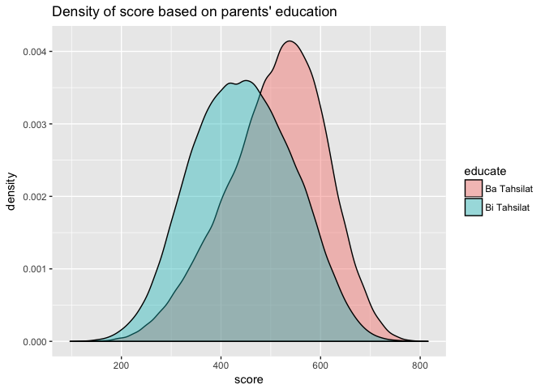

```r
edu_perf <- bsg %>% select(idstud, idcntry, edu = bsdgedup, contains("bsssci"), contains("bsmmat")) %>%
  mutate(sci = rowMeans(.[, 4:8]), math = rowMeans(.[, 9:13])) %>%
  select(idstud, idcntry, edu, sci, math) %>%
  mutate(score = rowMeans(.[,4:5])) %>%
  select(idstud, idcntry, edu, score) %>%
  filter(edu != 6) %>%
  mutate(educate = ifelse(edu < 3, "Ba Tahsilat", "Bi Tahsilat"))

ggplot(edu_perf,aes(x = score,fill = educate)) + geom_density(alpha= 0.4) + ggtitle("Density of score based on parents' education")
```

```r
non_edu <- edu_perf %>% filter(educate == "Bi Tahsilat")
with_edu <- edu_perf %>% filter(educate == "Ba Tahsilat")

hchart(density(non_edu$score), type = "area", name=list("Bi Tahsilat")) %>%
  hc_add_series(density(with_edu$score), type = "area", name=list("Ba Tahsilat")) %>%
  hc_add_theme(hc_theme_flat()) %>%
  hc_yAxis(title = list(text = "density")) %>%
  hc_xAxis(title = list(text = "score"))
```

[interactive chart not shown]

همانطور که در نمودار می بینیم، مد نمرات دانش آموزان با تحصیلات از دانش آموزان بی تحصیلات به صورت محسوسی بیشتر است.

```r
t.test(non_edu$score, with_edu$score, alt = "less")
```

```
    Welch Two Sample t-test

data:  non_edu$score and with_edu$score
t = -146.22, df = 185870, p-value < 2.2e-16
alternative hypothesis: true difference in means is less than 0
95 percent confidence interval:
      -Inf -63.70065
sample estimates:
mean of x mean of y
 444.7892  509.2146
```

برای مشاهده ی صحت فرض، بیشتر بودن نمره ی دانش آموزان با والدین بدون تحصیلات را از دانش آموزان با والدین با تحصیلات، تست می کنیم که همانطور که نتایج نشان می دهد، این احتمال بسیار کم بوده و در نتیجه فرض ما باطل است.  
فرزندانی که والدین با تحصیلاتی دارند نمرات بهتری از فرزندانی که والدین بی تحصیلات دارند کسب می کنند.

۳. امکانات رفاهی در خانه موجب پیشرفت تحصیلی می گردد.

برای حل این سوال از داده ی BSDG06S در bsg استفاده می کنیم که داشتن اینترنت و اتاق شخصی را نشان می دهد. سپس برای بدست آوردن امتیاز دانش آموز میان ستون های نمرات علوم و ریاضی میانگین میگیریم. در نهایت در صورتی که دانش آموز یکی از موارد اتاق یا اینترنت را داشت او را با منابع تعریف کرده و در غیر این صورت بدون منابع تعریف می کنیم.

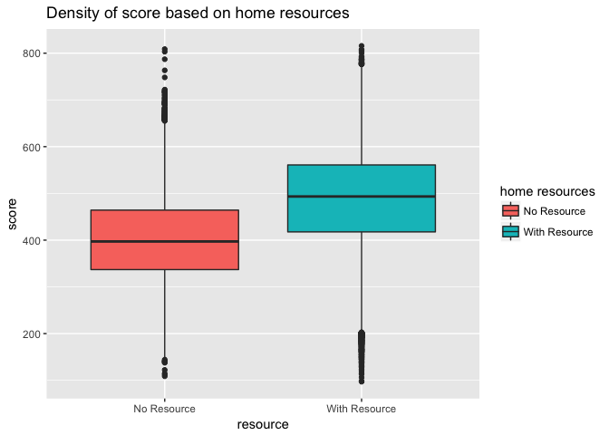

```r
edu_resources <- bsg %>% select(idstud, idcntry, std_rsc = bsdg06s, contains("bsssci"), contains("bsmmat"), edu_rsc = bsdgher) %>%
  mutate(score = rowMeans(.[, 4:13])) %>%
  select(idstud, idcntry, std_rsc, edu_rsc, score) %>%
  mutate(study_resource = ifelse(std_rsc < 1, "No Resource", "With Resource")) %>%
  select(idstud, idcntry, study_resource, edu_resource=edu_rsc, score) %>%
  filter(!is.na(study_resource)) %>%
  filter(!is.na(edu_resource))


edu_resources %>% ggplot(mapping = aes(study_resource, score, fill = study_resource)) +
  geom_boxplot(notch=FALSE) +
  ylab("score") +
  xlab("resource") +
  ggtitle("Density of score based on home resources") +
  guides(fill=guide_legend(title="home resources"))
```

```r
no_resource <- edu_resources %>% filter(study_resource == "No Resource")
with_resource <- edu_resources %>% filter(study_resource == "With Resource")


hchart(density(no_resource$score), type = "area", name=list("No Resource")) %>%
  hc_add_series(density(with_resource$score), type = "area", name=list("With Resource")) %>%
  hc_add_theme(hc_theme_google()) %>%
  hc_yAxis(title = list(text = "density")) %>%
  hc_xAxis(title = list(text = "score")) %>%
  hc_title(text = "Density of score based on home resources", style = list(fontWeight = "bold"))
```

[interactive chart not shown]

همانطور که در نمودار می بینیم، مد داده های دانش آموزان با منابع بیشتر از دانش آموزان بدون منابع است. در نتیجه انتظار داریم که منابع در نمره ی دانش آموزان تاثیر داشته باشند.

```r
t.test(no_resource$score, with_resource$score, alt = "less")
```

```
    Welch Two Sample t-test

data:  no_resource$score and with_resource$score
t = -125.69, df = 24964, p-value < 2.2e-16
alternative hypothesis: true difference in means is less than 0
95 percent confidence interval:
      -Inf -83.42941
sample estimates:
mean of x mean of y
 402.7753  487.3111
```

برای مشاهده ی صحت فرض، احتمال بیشتر بودن نمره ی دانش آموز بدون منابع را از دانش آموز با منابع تست می کنیم. همانطور که نتیجه نشان می دهد این احتمال بسیار پایین است، پس فرض رد می شود و منابع در امتیاز دانش آموز تاثیر گذار است.

برای حل این سوال از داده ی BSDGHER در bsg استفاده می کنیم که داشتن اینترنت و اتاق شخصی را نشان می دهد. سپس برای بدست آوردن امتیاز دانش آموز میان ستون های نمرات علوم و ریاضی میانگین میگیریم.

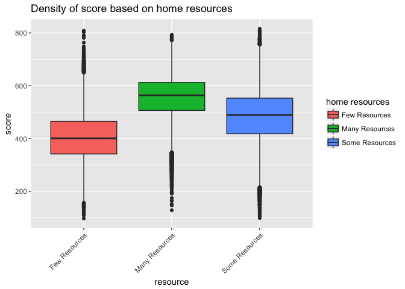

```r
# other data with anova
edu_resources <- edu_resources %>% mutate(edu_stuff = ifelse(edu_resource == 1, "Many Resources", ifelse(edu_resource == 2, "Some Resources", "Few Resources")))
edu_resources %>% ggplot(mapping = aes(edu_stuff, score, fill = edu_stuff)) +
  geom_boxplot(notch=FALSE) +
  ylab("score") +
  xlab("resource") +
  ggtitle("Density of score based on home resources") +
  guides(fill=guide_legend(title="home resources")) +
  theme(axis.text.x = element_text(angle = 45, hjust = 1))
```

```r
few_resource <- edu_resources %>% filter(edu_resource == 3)
some_resource <- edu_resources %>% filter(edu_resource == 2)
many_resource <- edu_resources %>% filter(edu_resource == 1)

hchart(density(few_resource$score), name=list("Few Resources")) %>%
  hc_add_series(density(some_resource$score), name=list("Some Resources")) %>%
  hc_add_series(density(many_resource$score), name=list("Many Resources")) %>%
  hc_add_theme(hc_theme_google()) %>%
  hc_yAxis(title = list(text = "density")) %>%
  hc_xAxis(title = list(text = "score")) %>%
  hc_title(text = "Density of score based on home resources", style = list(fontWeight = "bold"))
```

[interactive chart not shown]

همانطور که در نمودار دیده می شود، مد نمرات دانش آموزان با منابع بسیار از دانش آموزان با منابع متوسط بیشتر بوده و هر دو این نمرات از نمرات دانش آموزان با منابع کم بیشتر بوده اند. پس انتظار داریم که منابع تاثیر داشته باشد.

```r
summary(aov(score ~ edu_resource, data = edu_resources))
```

```
                 Df    Sum Sq   Mean Sq F value Pr(>F)
edu_resource      1 4.382e+08 438203648   49438 <2e-16 ***
Residuals    268030 2.376e+09      8864
---
Signif. codes:  0 '***' 0.001 '**' 0.01 '*' 0.05 '.' 0.1 ' ' 1
```

۴. محیط آرام مدرسه نقش مهمی در پیشرفت تحصیلی دارد.

۵. معلمان با تحصیلات بالاتر یا تجربه بیشتر دانش آموزان موفق تری تربیت می کنند.

برای حل این سوال برای بدست آوردن تحصیلات معلمان از ستون BTBG04 در داده ی btm استفاده می کنیم که میزان تحصیلات معلم را در چند دسته نمایش می دهد. سپس برای بدست آوردن امتیاز دانش آموز میان ستون های نمرات علوم و ریاضی میانگین میگیریم. در نهایت این دو جدول را از روی کشور و شناسه ی معلم join می کنیم.

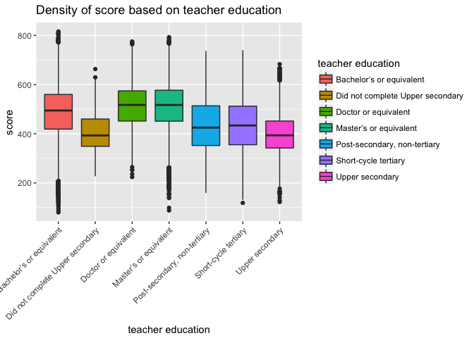

```r
tchr_std_perf <- bst %>% select(country= idcntry, teacher= idteach, student= idstud, contains("bsssci"), contains("bsmmat"), school= idschool) %>%
  mutate(score = rowMeans(.[, 4:13])) %>%
  select(country, teacher, student, school, score) %>%
  filter(!is.na(country) & !is.na(teacher) & !is.na(student) & !is.na(school) & !is.na(score))

tchr_bg <- btg %>% select(country= idcntry, teacher= idteach, school= idschool, edu= btbg04) %>%
  filter(!is.na(country) & !is.na(teacher) & !is.na(school) & !is.na(edu))

tchr_bg_std_perf <- tchr_std_perf %>% inner_join(tchr_bg, by= c("country", "teacher", "school"))

group1 <- tchr_bg_std_perf %>% filter(edu == 1)
group2 <- tchr_bg_std_perf %>% filter(edu == 2)
group3 <- tchr_bg_std_perf %>% filter(edu == 3)
group4 <- tchr_bg_std_perf %>% filter(edu == 4)
group5 <- tchr_bg_std_perf %>% filter(edu == 5)
group6 <- tchr_bg_std_perf %>% filter(edu == 6)
group7 <- tchr_bg_std_perf %>% filter(edu == 7)

tchr_bg_std_perf <- tchr_bg_std_perf %>%
  mutate(education = ifelse(edu == 1, "Did not complete Upper secondary",
                ifelse(edu == 2, "Upper secondary",
                       ifelse(edu == 3, "Post-secondary, non-tertiary",
                              ifelse(edu == 4, "Short-cycle tertiary",
                                     ifelse(edu == 5, "Bachelor’s or equivalent",
                                            ifelse(edu == 6, "Master’s or equivalent",
                                                   ifelse(edu == 7, "Doctor or equivalent", NA)))))))) %>%
  select(country, teacher, student, school, score, education) %>%
  filter(!is.na(education))

tchr_bg_std_perf %>% ggplot(mapping = aes(education, score, fill = education)) +
  geom_boxplot(notch=FALSE) +
  ylab("score") +
  xlab("teacher education") +
  ggtitle("Density of score based on teacher education") +
  guides(fill=guide_legend(title="teacher education")) +
  theme(axis.text.x = element_text(angle = 45, hjust = 1))
```

```r
hchart(density(group1$score), name=list("Did not complete Upper secondary")) %>%
  hc_add_series(density(group2$score), name=list("Upper secondary")) %>%
  hc_add_series(density(group3$score), name=list("Post-secondary, non-tertiary")) %>%
  hc_add_series(density(group4$score), name=list("Short-cycle tertiary")) %>%
  hc_add_series(density(group5$score), name=list("Bachelor’s or equivalent")) %>%
  hc_add_series(density(group6$score), name=list("Master’s or equivalent")) %>%
  hc_add_series(density(group7$score), name=list("Doctor or equivalent")) %>%
  hc_add_theme(hc_theme_google()) %>%
  hc_yAxis(title = list(text = "density")) %>%
  hc_xAxis(title = list(text = "score")) %>%
  hc_title(text = "Density of score based on teacher education", style = list(fontWeight = "bold"))
```

[interactive chart not shown]

همانطور که نمودارها نشان می دهند، تحصیلات معلم تاثیر گذار است و هرچه تحصیلات معلم بیشتر باشد، نتایج دانش آموزان بهتر می شود.

```r
summary(aov(score ~ education, data = tchr_bg_std_perf))
```

```
                Df    Sum Sq  Mean Sq F value Pr(>F)
education        6 1.638e+08 27303976    2839 <2e-16 ***
Residuals   301260 2.897e+09     9616
---
Signif. codes:  0 '***' 0.001 '**' 0.01 '*' 0.05 '.' 0.1 ' ' 1
```

```r
t.test(group7$score, group1$score, alt="greater")
```

```
    Welch Two Sample t-test

data:  group7$score and group1$score
t = 24.805, df = 740.14, p-value < 2.2e-16
alternative hypothesis: true difference in means is greater than 0
95 percent confidence interval:
 96.47216      Inf
sample estimates:
mean of x mean of y
 512.5936  409.2606
```

برای تست صحت فرض، برابر بودن امتیاز دانش آموزان هر دسته را با ANOVA تست می کنیم، همانطور که نتایج نشان می دهد، احتمال بسیار کم بوده، پس تحصیلات معلم در نتایج تاثیر گذار است. همچنین تست دوم نشان می دهد که معلمان با تحصیلات بیشتر نتایج بهتری میگیرند.(در واقع احتمال اینکه دانش آموز با معلم با تحصیلات بدتر نتایج بهتری بگیرند بسیار کم است)

۶. پسران در کاربرد هندسه قوی تر هستند.

برای حل این سوال برای بدست آوردن هندسه میان ستون های BSMGEO در داده ی bsa میانگین میگیریم.

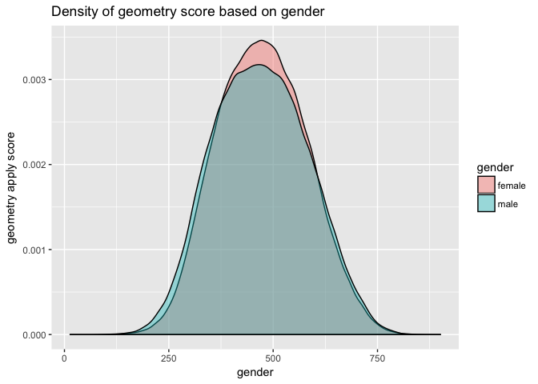

```r
apply_geo <- bsa %>% select(country= idcntry, student= idstud, sex= itsex, contains("bsmgeo")) %>%
  mutate(score = rowMeans(.[, 4:8])) %>%
  mutate(gender = ifelse(sex == 1, "female",
                         ifelse(sex == 2, "male", NA))) %>%
  select(country, student, gender, score) %>%
  filter(!is.na(country) & !is.na(student) & !is.na(gender) & !is.na(score))


ggplot(apply_geo, aes(x = score, fill = gender)) + geom_density(alpha= 0.4) + ggtitle("Density of geometry score based on gender") +
  ylab("geometry apply score") +
  xlab("gender") +
  guides(fill=guide_legend(title="gender"))
```

```r
group1 <- apply_geo %>% filter(gender == "female")
group2 <- apply_geo %>% filter(gender == "male")

hchart(density(group1$score), type = "area", name=list("female")) %>%
  hc_add_series(density(group2$score), type = "area", name=list("male")) %>%
  hc_yAxis(title = list(text = "density")) %>%
  hc_xAxis(title = list(text = "score")) %>%
  hc_add_theme(hc_theme_db()) %>%
  hc_title(text = "Density of geometry score based on gender", style = list(fontWeight = "bold"))
```

[interactive chart not shown]

همانطور که در نمودار میبینیم، دو دسته تفاوت زیادی ندارند.

```r
t.test(score~gender, data = apply_geo, alt = 'greater')
```

```
    Welch Two Sample t-test

data:  score by gender
t = 9.2376, df = 279150, p-value < 2.2e-16
alternative hypothesis: true difference in means is greater than 0
95 percent confidence interval:
 3.13238     Inf
sample estimates:
mean in group female   mean in group male
            474.3713             470.5604
```

برای صحت فرض، احتمال بیشتر بودن نمرات پسران از دختران را به کمک t.test تست می کنیم که همانطور که نشان می دهد، احتمال بسیار کم بوده و عملکرد هندسه ی پسران از دختران بهتر نیست.

۷. تغذیه دانش آموزان نقش اساسی در یادگیری آنها دارد.

برای حل این سوال از ستون های BCBG06a و BCBG06b را از داده ی bcg استفاده می کنیم که مجانی بودن ناهار یا صبحانه را از طرف مدرسه نشان می دهد. در نهایت غذای مدرسه را به ۹ گروه مجانی برای همه، مجانی برای عده ای و غیرمجانی تقسیم می کنیم.

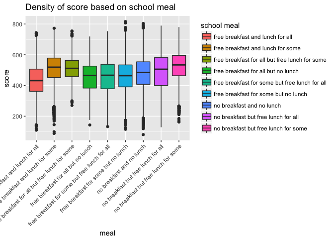

```r
schl_meal <- bcg %>% select(country= idcntry, school= idschool, contains("bcbg06")) %>%
  filter(!is.na(country) & !is.na(school) & !is.na(bcbg06a) & !is.na(bcbg06b)) %>%
  mutate(meal = ifelse(bcbg06a == 1 & bcbg06b == 1, "free breakfast and lunch for all",
                       ifelse(bcbg06a == 1 & bcbg06b == 2, "free breakfast for all but free lunch for some",
                              ifelse(bcbg06a == 1 & bcbg06b == 3, "free breakfast for all but no lunch",
                                     ifelse(bcbg06a == 2 & bcbg06b == 1, "free breakfast for some but free lunch for all",
                                            ifelse(bcbg06a == 2 & bcbg06b == 2, "free breakfast and lunch for some",
                                                   ifelse(bcbg06a == 2 & bcbg06b == 3, "free breakfast for some but no lunch",
                                                          ifelse(bcbg06a == 3 & bcbg06b == 1, "no breakfast but free lunch for all",
                                                                 ifelse(bcbg06a == 3 & bcbg06b == 2, "no breakfast but free lunch for some",
                                                                        ifelse(bcbg06a == 3 & bcbg06b == 3, "no breakfast and no lunch", NA)))))))))) %>%
  filter(!is.na(meal)) %>%
  select(country, school, meal)

schl_score <- bsg %>% select(country= idcntry, school=idschool, student= idstud, contains("bsssci"), contains("bsmmat")) %>%
  mutate(score = rowMeans(.[, 4:13])) %>%
  select(country, school, student, score)

meal_score <- schl_score %>% full_join(schl_meal, by = c("country", "school")) %>%
  filter(!is.na(country) & !is.na(school) & !is.na(score) & !is.na(meal))

meal_score %>% ggplot(mapping = aes(meal, score, fill = meal)) +
  geom_boxplot(notch=FALSE) +
  ylab("score") +
  xlab("meal") +
  ggtitle("Density of score based on school meal") +
  guides(fill=guide_legend(title="school meal")) +
  theme(axis.text.x = element_text(angle = 45, hjust = 1))
```

```r
hchart(density(filter(meal_score, meal == "free breakfast and lunch for all")$score), name=list("free breakfast and lunch for all")) %>%
  hc_add_series(density(filter(meal_score, meal == "free breakfast for all but free lunch for some")$score), name=list("free breakfast for all but free lunch for some")) %>%
  hc_add_series(density(filter(meal_score, meal == "free breakfast for all but no lunch")$score), name=list("free breakfast for all but no lunch")) %>%
  hc_add_series(density(filter(meal_score, meal == "free breakfast for some but free lunch for all")$score), name=list("free breakfast for some but free lunch for all")) %>%
  hc_add_series(density(filter(meal_score, meal == "free breakfast and lunch for some")$score), name=list("free breakfast and lunch for some")) %>%
  hc_add_series(density(filter(meal_score, meal == "free breakfast for some but no lunch")$score), name=list("free breakfast for some but no lunch")) %>%
  hc_add_series(density(filter(meal_score, meal == "no breakfast but free lunch for all")$score), name=list("no breakfast but free lunch for all")) %>%
  hc_add_series(density(filter(meal_score, meal == "no breakfast but free lunch for some")$score), name=list("no breakfast but free lunch for some")) %>%
  hc_add_series(density(filter(meal_score, meal == "no breakfast and no lunch")$score), name=list("no breakfast and no lunch")) %>%
  hc_add_theme(hc_theme_flat()) %>%
  hc_yAxis(title = list(text = "density")) %>%
  hc_xAxis(title = list(text = "score")) %>%
  hc_title(text = "Density of score based on school meal", style = list(fontWeight = "bold"))
```

[interactive chart not shown]

همانطور که در نمودار می بینیم، تغذیه تاثیر بر روی نتایج دارد، اما نتایج معنی داری وجود ندارد. برای مثال کمترین امتیاز را دانش آموزان با تغذیه مجانی دریافت می کنند و یا بیشترین امتیاز را دانش آموزان بدون صبحانه مجانی و غذای مجانی برای عده ای گرفته اند. البته می بینیم که دانش آموزان با ناهار نتایج بهتری را کسب می کنند.

```r
summary(aov(score ~ education, data = tchr_bg_std_perf))
```

```
                Df    Sum Sq  Mean Sq F value Pr(>F)
education        6 1.638e+08 27303976    2839 <2e-16 ***
Residuals   301260 2.897e+09     9616
---
Signif. codes:  0 '***' 0.001 '**' 0.01 '*' 0.05 '.' 0.1 ' ' 1
```

```r
free_all <- meal_score %>% filter(meal == "free breakfast and lunch for all")
no_all <- meal_score %>% filter(meal == "no breakfast and no lunch")

t.test(free_all$score, no_all$score, alt= "two.sided")
```

```
    Welch Two Sample t-test

data:  free_all$score and no_all$score
t = -41.463, df = 11495, p-value < 2.2e-16
alternative hypothesis: true difference in means is not equal to 0
95 percent confidence interval:
 -46.80194 -42.57652
sample estimates:
mean of x mean of y
 435.0017  479.6909
```

هم چنین در تست بالا تست می کنیم که دانش آموزان بدون تغذیه با دانش آموزان با تغذیه نتایج یکسانی کسب می کنند که نشان می دهد که این موضوع منتفی است.

۸. مدارس با امکانات بیشتر دارای عملکرد بهتری می باشند.

۹. علت افت تحصیلی عدم مشارکت در کلاس است.

۱۰. دانش آموزان ایرانی در استدلال قوی تر از کاربرد هستند.

برای حل این سوال از داده ی tims استفاده می کنیم، که کشور ایران را انتخاب کرده و درصد درستی سوال و دو نوع سوال استدلالی و کاربرد را انتخاب می کنیم.

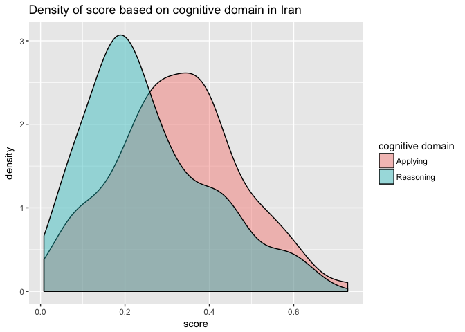

```r
irn <- tims %>% filter(Country == "Iran, Islamic Rep. of") %>%
  select(score = correct_ratio_per_question, type= cognitive_domain) %>%
  filter(type == "Applying" | type == "Reasoning")

ggplot(irn, aes(x = score, fill = type)) + geom_density(alpha= 0.4) + ggtitle("Density of score based on cognitive domain in Iran") +
  ylab("density") +
  xlab("score") +
  guides(fill=guide_legend(title="cognitive domain"))
```

```r
group1 <- irn %>% filter(type == "Applying")
group2 <- irn %>% filter(type == "Reasoning")

hchart(density(group1$score), type = "area", name=list("Applying")) %>%
  hc_add_series(density(group2$score), type = "area", name=list("Reasoning")) %>%
  hc_yAxis(title = list(text = "density")) %>%
  hc_xAxis(title = list(text = "score")) %>%
  hc_title(text = "Density of score based on cognitive domain in Iran", style = list(fontWeight = "bold"))
```

[interactive chart not shown]

همانطور که در نمودار می بینیم میانه ی نمرات سوالات کاربرد از نمرات سوالات استدلالی بیشتر است.

```r
t.test(score~type, data = irn, alt = 'greater')
```

```
    Welch Two Sample t-test

data:  score by type
t = 2.6374, df = 90.055, p-value = 0.00492
alternative hypothesis: true difference in means is greater than 0
95 percent confidence interval:
 0.02566765        Inf
sample estimates:
 mean in group Applying mean in group Reasoning
              0.3233984               0.2540000
```

برای تست صحت فرض، احتمال بیشتر بودن نمره ی سوالات استدلالی را تست می کنیم، که نتیجه نشان می دهد این احتمال بسیار پایین بوده و دانش آموزان در استدلال بهتر از کاربرد عمل نمی کنند.

سه گزاره جالب کشف کنید و ادعای خود را ثابت نمایید.

۱.دانش آموزانی که در بازی ها تنها می مانند، نتایج بدتری کسب می کنند.

برای حل این سوال، برای نمایش از بازی جا ماندن از ستون BSBG16B در داده ی bsg استفاده می کنیم که تعدد بازماندن دانش آموز از بازی را نشان می دهد. در صورتی که دانش آموز بیشتر از چند بار در سال بازبماند او را تنها به شمار آورده و در غیر این صورت تنها تلقی نمی کنیم.

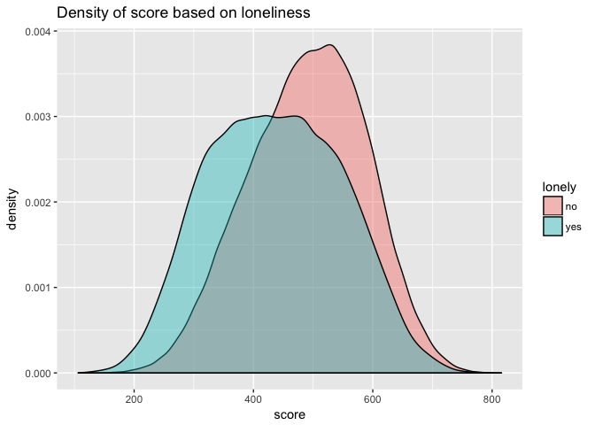

```r
#1.
# lonely students effect their score
lone <- bsg %>% select(student = idstud, country = idcntry, left= bsbg16b, contains("bsssci"), contains("bsmmat")) %>%
  mutate(score = rowMeans(.[, 4:13])) %>%
  filter(left < 5) %>%
  mutate(alone= ifelse(left < 3, "yes", "no")) %>%
  select(student, country, alone, score)

ggplot(lone, aes(x = score, fill = alone)) + geom_density(alpha= 0.4) + ggtitle("Density of score based on loneliness") +
  ylab("density") +
  xlab("score") +
  guides(fill=guide_legend(title="lonely"))
```

```r
group1 <- lone %>% filter(alone == "yes")
group2 <- lone %>% filter(alone == "no")

hchart(density(group1$score), type = "area", name=list("alone")) %>%
  hc_add_series(density(group2$score), type = "area", name=list("not alone")) %>%
  hc_yAxis(title = list(text = "density")) %>%
  hc_xAxis(title = list(text = "score")) %>%
  hc_title(text = "Density of score based on loneliness", style = list(fontWeight = "bold")) %>%
  hc_add_theme(hc_theme_google())
```

[interactive chart not shown]

همانطور که در نمودار می بینیم دانش آموزانی که بیشتر تنها می مانند، نمرات کمتری را از دسته ی دیگر کسب می کنند.

```r
t.test(score~alone, data = lone, alt="greater")
```

```
    Welch Two Sample t-test

data:  score by alone
t = 99.651, df = 68249, p-value < 2.2e-16
alternative hypothesis: true difference in means is greater than 0
95 percent confidence interval:
 52.97987      Inf
sample estimates:
 mean in group no mean in group yes
         490.7408          436.8718
```

برای تست صحت فرض، بیشتر بودن نمره ی دانش آموزان تنها را از دانش آموزان غیرتنها با t.test تست می کنیم که نتیجه نشان می دهد که عملکرد دانش آموزان تنها از دانش آموزان غیرتنها بهتر نیست.

۲. بحث کلاسی بیشتر باعث بهبود نتایج دانش آموزان است.

برای حل این سوال از ستون BTBG14D در داده ی btm استفاده می کنیم که میزان بحث کلاسی را نشان می دهد.

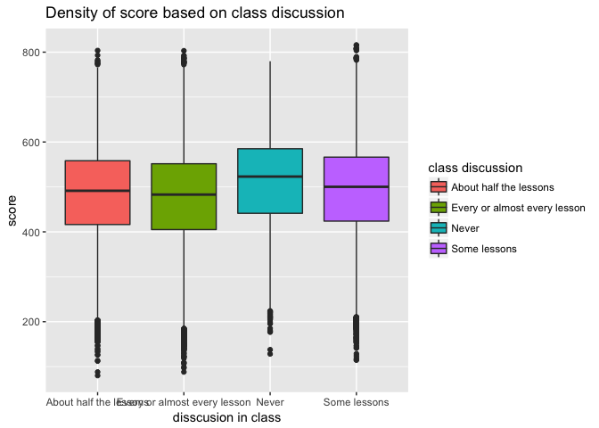

```r
#2
# teachers using discussion get better results
tchr_inq <- btg %>% select(country= idcntry, teacher= idteach, discus = btbg14d) %>%
  filter(!is.na(country) & !is.na(teacher) & !is.na(discus)) %>%
  filter(discus < 5)

discus_res <- tchr_inq %>% inner_join(tchr_std_perf, by=c("country", "teacher")) %>%
  mutate(discussion = ifelse(discus == 1, "Every or almost every lesson",
                             ifelse(discus == 2, "About half the lessons",
                                    ifelse(discus == 3, "Some lessons", "Never"))))

discus_res %>% ggplot(mapping = aes(discussion, score, fill = discussion)) +
  geom_boxplot(notch=FALSE) +
  ylab("score") +
  xlab("disscusion in class") +
  ggtitle("Density of score based on class discussion") +
  guides(fill=guide_legend(title="class discussion"))
```

```r
hchart(density(filter(discus_res, discussion == "Every or almost every lesson")$score), name=list("Every or almost every lesson")) %>%
  hc_add_series(density(filter(discus_res, discussion == "About half the lessons")$score), name=list("About half the lessons")) %>%
  hc_add_series(density(filter(discus_res, discussion == "Some lessons")$score), name=list("Some lessons")) %>%
  hc_add_series(density(filter(discus_res, discussion == "Never")$score), name=list("Never")) %>%
  hc_add_theme(hc_theme_ft()) %>%
  hc_yAxis(title = list(text = "density")) %>%
  hc_xAxis(title = list(text = "score")) %>%
  hc_title(text = "Density of score based on class discussion", style = list(fontWeight = "bold"))
```

[interactive chart not shown]

```r
summary(aov(score ~ discussion, data = discus_res))
```

```
                Df    Sum Sq Mean Sq F value Pr(>F)
discussion       3 1.963e+07 6541759   638.5 <2e-16 ***
Residuals   313956 3.217e+09   10246
---
Signif. codes:  0 '***' 0.001 '**' 0.01 '*' 0.05 '.' 0.1 ' ' 1
```

```r
discus_all <- discus_res %>% filter(discussion == "Every or almost every lesson")
discuss_no <- discus_res %>% filter(discussion == "Never")
t.test(discus_all$score, discuss_no$score, alt= "less")
```

```
    Welch Two Sample t-test

data:  discus_all$score and discuss_no$score
t = -25.131, df = 6745.6, p-value < 2.2e-16
alternative hypothesis: true difference in means is less than 0
95 percent confidence interval:
      -Inf -31.49611
sample estimates:
mean of x mean of y
 475.9872  509.6895
```

برای تست صحت فرض، احتمال بهتر بودن نتایج دانش آموزان با بیشترین بحث کلاسی را از نتایج دانش آموزان بدون بحث کلاسی را به کمک t.test تست می کنیم. نتیجه نشان می دهد که این احتمال بسیار کم بوده و بحث کلاسی بیشتر باعث بهبود نتایج نمی شود.

۳. گوشی موبایل باعث تضعیف نمرات دانش آموزان می شود.

برای حل این سوال از ستون BSBG06F از داده ی bsg استفاده می کنیم که داشتن تلفن همراه را تست می کند.

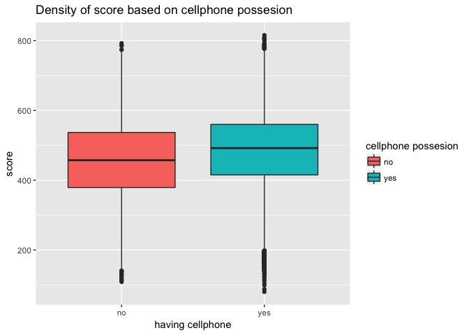

```r
#3
# cellphone worsen students performance

std_edu <- bsg %>% select(student= idstud, country= idcntry, cell= bsbg06f , contains("bsssci"), contains("bsmmat")) %>%
  mutate(score = rowMeans(.[, 4:13])) %>%
  filter(cell < 3) %>%
  filter(!is.na(country) & !is.na(student)) %>%
  mutate(cellphone= ifelse(cell == 1, "yes", "no")) %>%
  select(student, country, cellphone, score)

std_edu %>% ggplot(mapping = aes(cellphone, score, fill = cellphone)) +
  geom_boxplot(notch=FALSE) +
  ylab("score") +
  xlab("having cellphone") +
  ggtitle("Density of score based on cellphone possesion") +
  guides(fill=guide_legend(title="cellphone possesion"))
```

```r
hchart(density(filter(std_edu, cellphone == "yes")$score), name=list("yes")) %>%
  hc_add_series(density(filter(std_edu, cellphone == "no")$score), name=list("no")) %>%
  hc_yAxis(title = list(text = "density")) %>%
  hc_xAxis(title = list(text = "score")) %>%
  hc_title(text = "Density of score based on cellphone possesion", style = list(fontWeight = "bold"))
```

[interactive chart not shown]

همانطور که در نمودار می بینیم، دانش آموزان با تلفن همراه نمرات بهتری را نیز کسب کرده اند.

```r
t.test(score~cellphone, data= std_edu, alt="less")
```

```
    Welch Two Sample t-test

data:  score by cellphone
t = -54.753, df = 72952, p-value < 2.2e-16
alternative hypothesis: true difference in means is less than 0
95 percent confidence interval:
      -Inf -27.57896
sample estimates:
 mean in group no mean in group yes
         457.3682          485.8014
```

برای تست صحت فرض، احتمال کمتر بودن نمره ی دانش آموز با موبایل را از دانش آموزا بدون موبایل تست می کنیم که بسیار پایین است، پس داشتن تلفن همراه باعث تضعیف نمرات دانش آموزان نمی شود.